```r
Cereals<-read.csv("C:/Users/reape/OneDrive/Documents/Masters Program/Fundamentals of Machine Learning/Assignment 5/Cereals.csv")
```

```r
#Data Preprocessing
cereals_cleaned <- na.omit(Cereals)
```

```r
row.names(cereals_cleaned) <- cereals_cleaned$name
numeric_columns <- cereals_cleaned[, sapply(cereals_cleaned, is.numeric)]
Cereals_scaled <- scale(numeric_columns)
```

```r
d <- dist(Cereals_scaled, method = "euclidean")
```

```r
#Applying agnes to compare clustering from single linkage, complete linkage, average linkage, and Ward:
library(cluster)
hc_single <- agnes(Cereals_scaled, method = "single")
hc_complete <- agnes(Cereals_scaled, method = "complete")
hc_average <- agnes(Cereals_scaled, method = "average")
hc_ward <- agnes(Cereals_scaled, method = "ward")
print(hc_single$ac)
```

```
## [1] 0.6067859
```

```r
print(hc_complete$ac)
```

```
## [1] 0.8353712
```

```r
print(hc_average$ac)
```

```
## [1] 0.7766075
```

```r
print(hc_ward$ac)
```

```
## [1] 0.9046042
```

1. Comparing the the clustering from the agnes method using single linkage, complete, average, and Ward shows that Ward is the best method has it has the highest coefficient.

```r
hc1<-hclust(d,method = "ward")
```

```
## The "ward" method has been renamed to "ward.D"; note new "ward.D2"
```

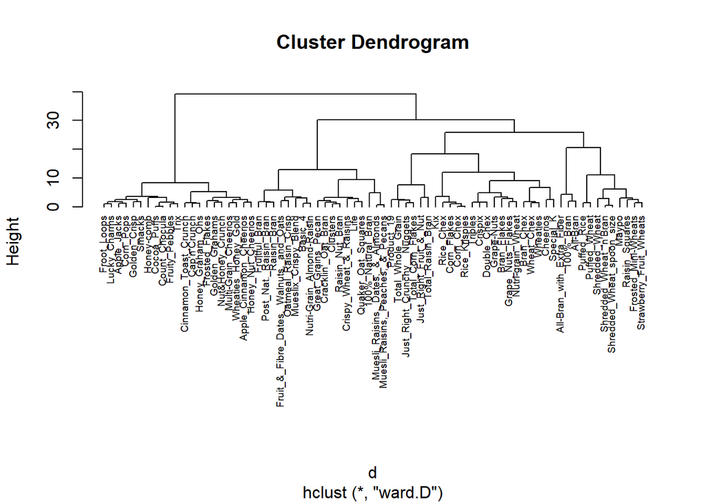

```r
plot(hc1,cex=0.6,hang=-1)
```

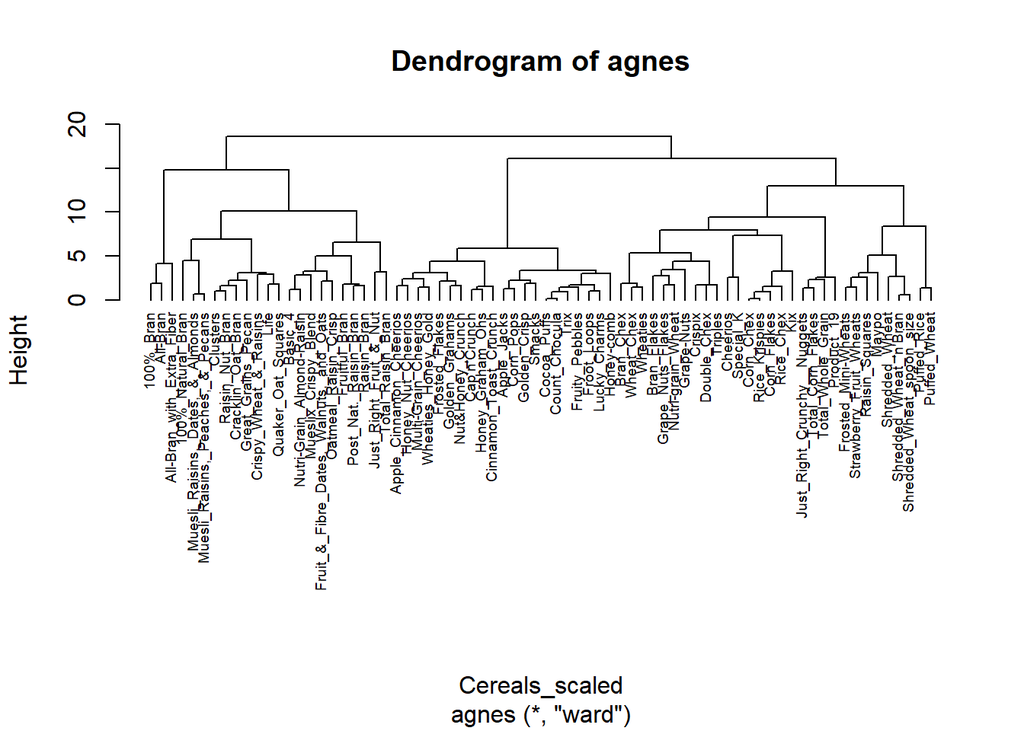

```r
pltree(hc_ward,cex=0.6,hang=-1,main="Dendrogram of agnes")
```

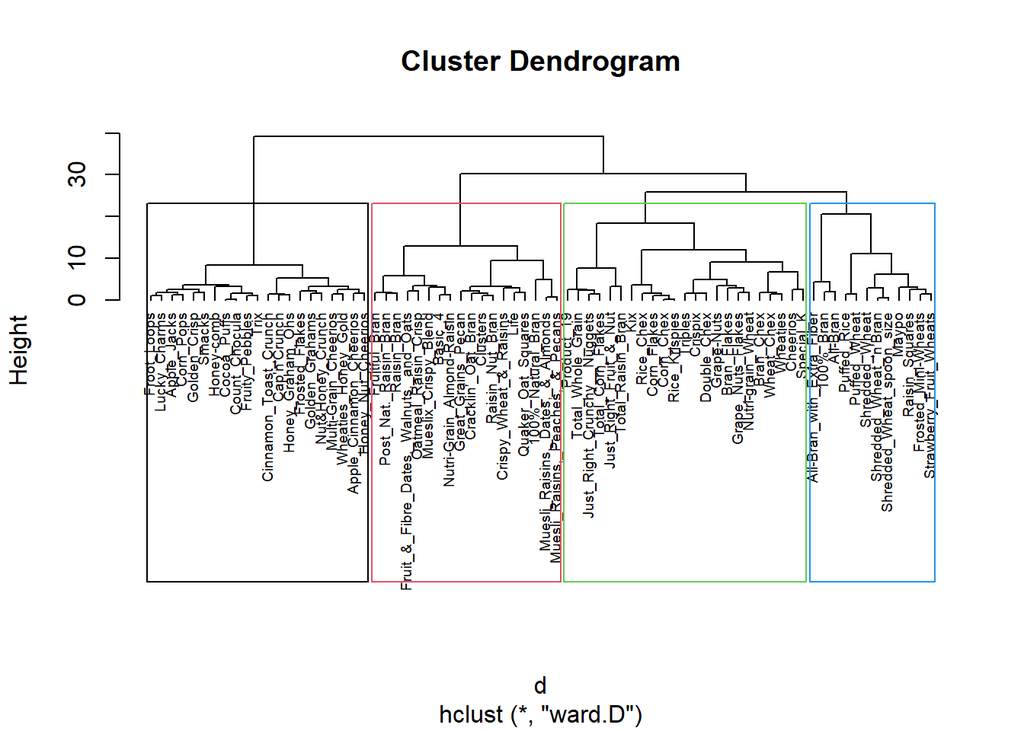

```r
plot(hc1,cex=0.6,hang=-1)
rect.hclust(hc1,k=4,border = 1:4)
```

```r
cereals_cleaned$cluster <- cutree(hc1, k = 4)
```

2. I chose 4 clusters as I believe that best suits the data shown in the dendrogram above based on the height of the vertical lines.

```r
set.seed(123)
partition_index <- sample(1:nrow(cereals_cleaned), size = 0.7 * nrow(cereals_cleaned))
partition_A <- cereals_cleaned[partition_index, ]
partition_B <- cereals_cleaned[-partition_index, ]
numeric_columns_A <- partition_A[, sapply(partition_A, is.numeric)]
partition_A$cluster <- cereals_cleaned$cluster[partition_index]
centroids_A <- aggregate(. ~ cluster, data = numeric_columns_A, FUN = mean)
```

```r
#Creating the for loop
euclidean <- function(a, b) sqrt(sum((a - b)^2))
assigned_clusters_B <- numeric(nrow(partition_B))
for (i in 1:nrow(partition_B)) {
  row_data <- partition_B[i, sapply(partition_B, is.numeric)]
  distances <- apply(centroids_A[, -1], 1, function(x) euclidean(x, row_data))
  assigned_clusters_B[i] <- which.min(distances)
}
```

```r
#Adding the clusters to partition B
partition_B$new_cluster <- assigned_clusters_B
```

```r
#Creating a table to compare the differences between the old and new clusters and check the stability
comparison_table <- table(partition_B$cluster, partition_B$new_cluster)
print(comparison_table)
```

```
##
##     1 2 3 4
##   1 2 2 0 0
##   2 2 2 1 0
##   3 1 0 2 2
##   4 0 0 1 8
```

The original cluster assignments are shown by rows and the new cluster assignments are shown by the columns. From this comparison table we can see that the stability of the clusters varies, with Cluster 4 showing high stability and Cluster 3 showing the least. Clusters 1 and 2 have moderate stability, with movements mainly between themselves.

```r
# Selecting the columns that indicate how healthy cereal is
health_vars <- cereals_cleaned[, c("calories", "protein", "fat", "fiber", "carbo", "sugars", "potass", "vitamins")]
```

```r
# Normalizing the data because the variable ranges are very different from each other
health_vars_scaled <- scale(health_vars)
```

```r
d <- dist(health_vars_scaled, method = "euclidean")
hc <- hclust(d, method = "ward")
```

```
## The "ward" method has been renamed to "ward.D"; note new "ward.D2"
```

```r
num_clusters <- 4
cereals_cleaned$cluster <- cutree(hc, k = num_clusters)
```

```r
#Making sure to only select numeric columns
numeric_columns <- cereals_cleaned[, sapply(cereals_cleaned, is.numeric)]
```

```r
# Creating and printing the cluster summary
cluster_summary <- aggregate(. ~ cluster, data = numeric_columns, FUN = mean)
print(cluster_summary)
```

```
##   cluster calories  protein       fat   sodium     fiber    carbo    sugars
## 1       1 112.6923 3.461538 1.7307692 162.3077 3.6538462 12.88462  7.769231
## 2       2 111.6667 1.388889 0.9444444 165.0000 0.3888889 12.66667 11.722222
## 3       3  95.0000 2.291667 0.2916667 148.9583 2.0000000 17.41667  3.125000
## 4       4 116.6667 2.666667 0.8333333 208.3333 1.8333333 18.16667  6.333333
##      potass  vitamins    shelf   weight      cups   rating
## 1 155.76923  24.03846 2.576923 1.101923 0.6926923 43.88578
## 2  39.72222  25.00000 1.777778 1.000000 0.8961111 28.06253
## 3  81.25000  19.79167 1.958333 0.951250 0.8712500 52.53193
## 4  95.83333 100.00000 3.000000 1.133333 0.9583333 38.09835
```

Yes normalization is needed because some of the number ranges for the variables are vastly different from each other. For example, the range for calories is 50 - 160, whereas the range for protein is 1-6. Out of the 4 clusters, I believe cluster 3 to contain the healthiest cereals. This is because:

It has the lowest calorie count.  
It has a decent amount of protein.  
It has the lowest fat content.  
The fiber content is the 2nd highest of the clusters.  
It has the second highest carbo content, but only a small portion of that content is from sugar.  
It has the lowest sugar content.  
It has the the third highest potassium content.  
It has he lowest vitamin content, but I the other parts of the cereal are very high on the healthy scale so this is okay.